## Course: Visual Analytics for Policy and Management

### Prof. José Manuel Magallanes, PhD

# Part 2: Visualizing Tabular data

### Univariate Case

Contents:

1. Intro.
2. Data Types.
3. Data Processes.

   3.1 Classification.
   - Nominal Data.
   - Ordinal Data.

   3.2 Counting.

   3.3 Measurement.

Most data are commonly organized in tabular format, that is, tables. When data is in tabular format, cases are organized in rows, while variables (information about the cases) are organized in columns. Almost every data you have used in a spreadsheet follows that structure.

For example, when you visit the [website](https://nces.ed.gov/ccd/) of the Common Core of Data from the US Department of Education, you can get a data set with detailed information on public schools at the state of Washington. Let me get a data table I have based on that:

```r
link='https://github.com/EvansDataScience/VisualAnalytics_2_tabularData/raw/master/data/eduwa.rda'

#getting the data TABLE from the file in the cloud:
load(file=url(link))
```

When you are in RStudio, you can view the data table by clicking on its name at the *Environment* .

It also good to know *how much* info you have:

```r
#number of rows and columns
dim(eduwa) #nrow(eduwa) ncol(eduwa)
```

```
## [1] 2427   24
```

This is the list of the 24 columns:

```r
names(eduwa)
```

```
##  [1] "NCES.School.ID"        "State.School.ID"
##  [3] "NCES.District.ID"      "State.District.ID"
##  [5] "Low.Grade"             "High.Grade"
##  [7] "School.Name"           "District"
##  [9] "County"                "Street.Address"
## [11] "City"                  "State"
## [13] "ZIP"                   "ZIP.4-digit"
## [15] "Phone"                 "Locale.Code"
## [17] "LocaleType"            "LocaleSub"
## [19] "Charter"               "Title.I.School"
## [21] "Title.1.School.Wide"   "Student.Teacher.Ratio"
## [23] "Free.Lunch"            "Reduced.Lunch"
```

When dealing with tabular data, you can suspect that you can produce a visualization for each column, and then for a couple of them simultaneously, and then for three or more.

In this material, we will pay attention to the *univariate* case; which is common for searching problems or veryfing outcomes; not for giving explanations. Then, when dealing with univariate data, you need to be aware of two things: *what question you are trying to answer*; and *how to treat a particular variable* to build the plot that will answer that question.

Go to table of contents.

## Data Types

I can not anticipate all the questions you can try to answer via plots; but I can tell you that you are always limited by the **nature** of the variables you have at hand. Generally speaking, you have either *categorical* or *numerical* data in each column, and whatever question you have, you first need to know how that variable you are planing to use has been encoded, so you can plan the treatment. In R, we can know that like this:

```r
# this 'width = 70,strict.width='cut' means
# you do not want to see more than 70 characters per row.

str(eduwa,width = 70,strict.width='cut')
```

```
## 'data.frame':    2427 obs. of  24 variables:
##  $ NCES.School.ID       : chr  "530486002475" "530270001270" "53091"..
##  $ State.School.ID      : chr  "WA-31025-1656" "WA-06114-1646" "WA-"..
##  $ NCES.District.ID     : chr  "5304860" "5302700" "5309100" "53000"..
##  $ State.District.ID    : chr  "WA-31025" "WA-06114" "WA-34033" "WA"..
##  $ Low.Grade            : Ord.factor w/ 14 levels "PK"<"KG"<"1"<..: ..
##  $ High.Grade           : Ord.factor w/ 15 levels "PK"<"KG"<"1"<..: ..
##  $ School.Name          : chr  "10th Street School" "49th Street Ac"..
##  $ District             : chr  "Marysville School District" "Evergr"..
##  $ County               : chr  "Snohomish" "Clark" "Thurston" "Gray"..
##  $ Street.Address       : chr  "7204 27th Ave NE" "14619B NE 49th S"..
##  $ City                 : chr  "Marysville" "Vancouver" "Tumwater" "..
##  $ State                : chr  "WA" "WA" "WA" "WA" ...
##  $ ZIP                  : chr  "98271" "98682" "98512" "98520" ...
##  $ ZIP.4-digit          : chr  NA "6308" NA "5510" ...
##  $ Phone                : chr  "(360)965-0400" "(360)604-6700" "(36"..
##  $ Locale.Code          : Factor w/ 12 levels "11","12","13",..: 5 2..
##  $ LocaleType           : Factor w/ 4 levels "City","Rural",..: 3 1 ..
##  $ LocaleSub            : Factor w/ 12 levels "City: Small",..: 5 2 ..
##  $ Charter              : Factor w/ 2 levels "No","Yes": 1 1 1 1 1 1..
##  $ Title.I.School       : Factor w/ 2 levels "No","Yes": 2 1 1 2 1 1..
##  $ Title.1.School.Wide  : Factor w/ 2 levels "No","Yes": 2 NA NA 2 N..
##  $ Student.Teacher.Ratio: num  23.4 8.4 21.5 15.9 6.5 15.3 NA 16.3 1..
##  $ Free.Lunch           : num  28 53 169 292 12 411 48 102 101 268 ...
##  $ Reduced.Lunch        : num  3 9 40 10 4 23 12 22 23 0 ...
```

The ones that say **num** are obviously numbers (numbers in R are *numeric* when decimal values are detected, and *integer* if they are not). The ones that say **chr** are strings, which are *candidates* to be **key** columns, which are not variables themselves, but identifiers of the cases. In this case, the first four are identifiers, as well as the the 7th, 10th and 15th columns (*school names*, *address* and *phone*, respectively). Those variables are not to be analyzed statistically, but may be used for annotating (7th and 15th column) or for geocoding (10th column). Notice that for these data, *State* is not to be analyzed as it is a constant (all rows are from WA); but it would be if the data were from the whole USA. Then, you see several variables identified as *factor* or *ordered factor*, which are categorical variables: they can be analyzed statistically but not in the same way that numbers.

Go to table of contents.

## Data Processes

Data is obtained via different processes. When you observe reality, you can *classsify*, *count* or *measure*. Each of these decisions produces data with some basic characteristics; which are represented via categories or numerical values.

### Classification

Categorical data are the output of the classification process. The classification can propose an incremental or non-incremental differentiation. The former are named ordinal data and the latter nominal data. A nominal classification related to education can be type of school funding: public or private; while an ordinal one can be: elementary, middle, high, college and graduate school level.

#### 1. Visualization for nominal scales

Let’s see some raw values in the variable **LocaleType**:

```r
head(eduwa$LocaleType,50) #first fifty values
```

```
##  [1] Suburb City   City   Town   City   City   Suburb City   Rural  Rural
## [11] City   City   City   City   Suburb Rural  Rural  Rural  Suburb City
## [21] Suburb Suburb Suburb Suburb City   City   Suburb Suburb Rural  Rural
## [31] Rural  Suburb City   City   Rural  City   City   Rural  Rural  City
## [41] Town   Town   Rural  City   Suburb City   City   Rural  City   City
## Levels: City Rural Suburb Town
```

You can not get a clear idea of what a data table has, so a simple **frequency table** is the first tool to see what these nominal data are telling us:

```r
# absolute values
table(eduwa$LocaleType,exclude = 'nothing')
```

```
##
##   City  Rural Suburb   Town   <NA>
##    714    505    798    338     72
```

```r
# relative values
absoluteT=table(eduwa$LocaleType,exclude = 'nothing')
prop.table(absoluteT)
```

```
##
##       City      Rural     Suburb       Town       <NA>
## 0.29419036 0.20807581 0.32880099 0.13926658 0.02966625
```

This table tells us the location of the public schools. What is the right visual for this? Sometimes the answer seems obvious, as tradition or habits give so much weight to decisions. Let’s use the very well known **pie chart**:

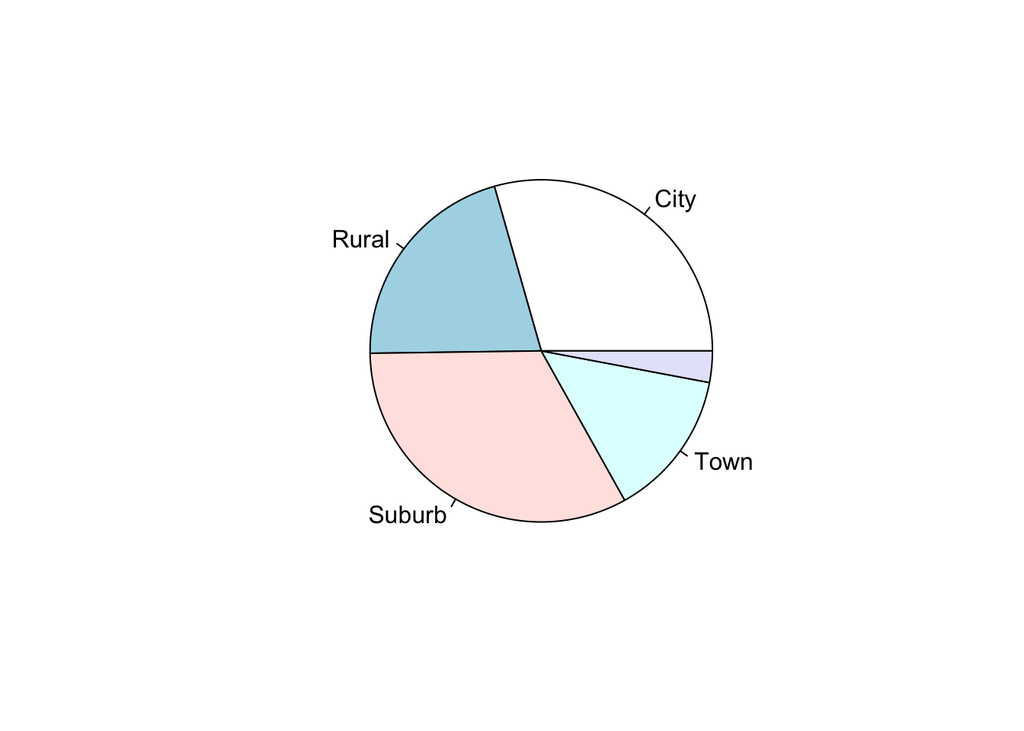

```r
# the pie plots the table:
ToPlot=prop.table(absoluteT)
pie(ToPlot)
```

You should always keep it simple. Then decorate. For example, you can start improving the plot you already *have*:

- The purple sector does not show a label:

```r
names(ToPlot)
```

```
## [1] "City"   "Rural"  "Suburb" "Town"   NA
```

We could alter the fifth label:

```r
names(ToPlot)[5]='Unknown'
```

- Our plot did not have a title. Titles (and subtitles) are important. To give a title, it can be a *question* to be answered by the plot:

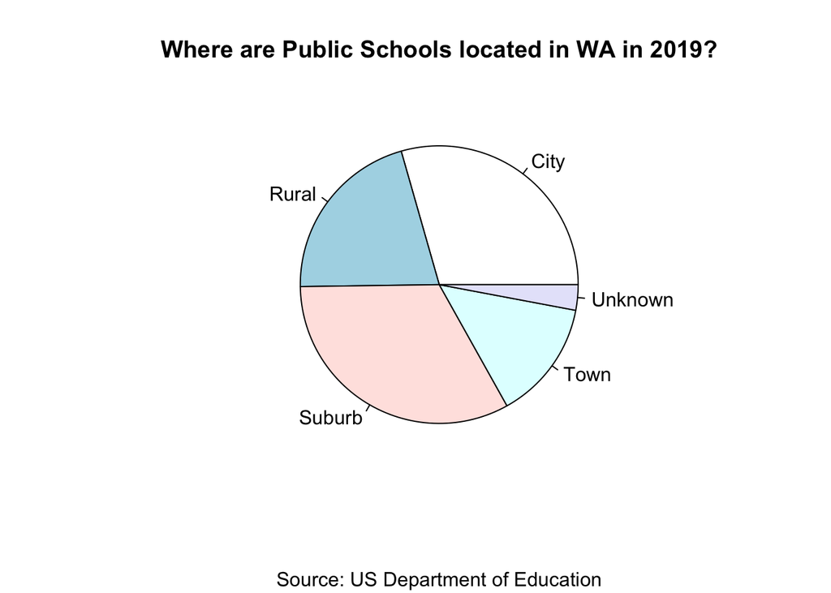

```r
# the pie plots the table:
titleText='Where are Public Schools located in WA in 2019?'
sourceText='Source: US Department of Education'

pie(ToPlot,
    main=titleText,
    sub=sourceText)
```

The title can *guide* the reader to recognise the purpose of your plot:

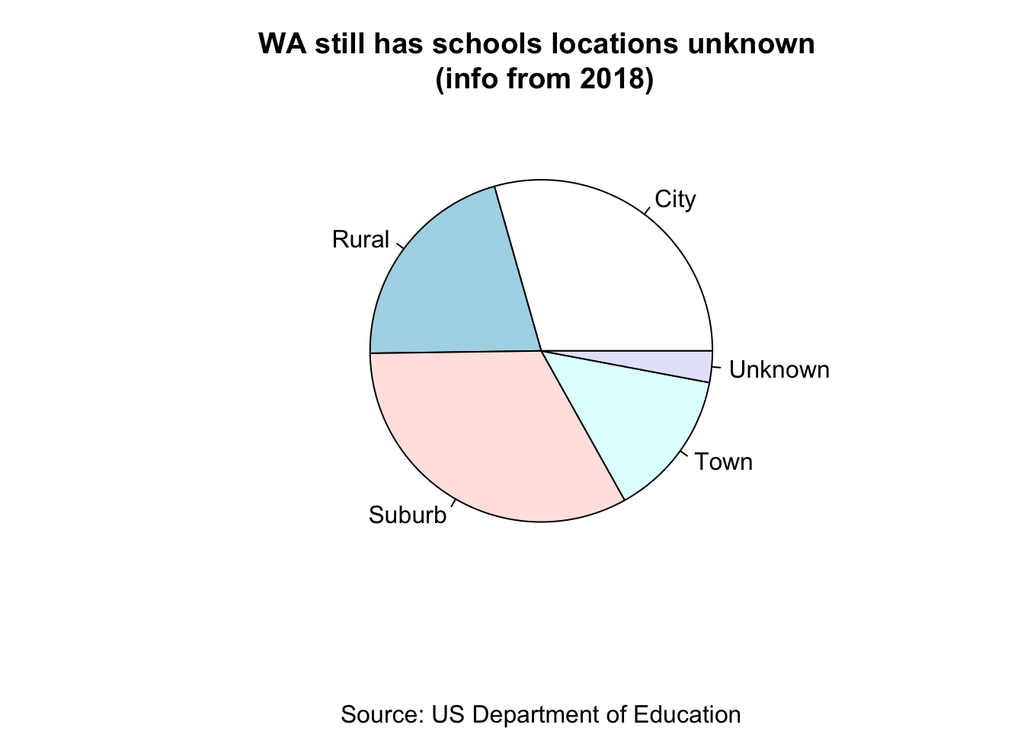

```r
# the pie plots the table:
titleText2='WA still has schools locations unknown \n (info from 2018)'

pie(ToPlot,
    main=titleText2,
    sub=sourceText)
```

The title can also *suggest* the decision:

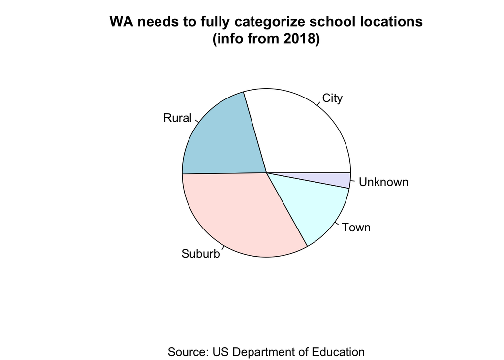

```r
# the pie plots the table:
titleText3='WA needs to fully categorize school locations\n(info from 2018)'

pie(ToPlot,
    main=titleText3,
    sub=sourceText)
```

Titles are no that easy to produce. You need to rewrite them many times, until you find a good combination of words that can be read in less than ten seconds. Is also good to keep in mind that you must never give your audience a cacophonous version (a *tongue twister*), and neither should you include adjectives.

A general rule for any plot is to make it reachable for the audience you are writing to (read [this](https://www.red-gate.com/simple-talk/sysadmin/general/5-steps-to-making-your-boss-read-your-technical-reports/) every day).

Let’s do more customization:

- You can use the values as labels. If values between [0,1] represent shares, it is better to use a [0,100] scale (in %).

```r
ToPlot*100
```

```
##      City     Rural    Suburb      Town   Unknown
## 29.419036 20.807581 32.880099 13.926658  2.966625
```

- You can customize the colors:

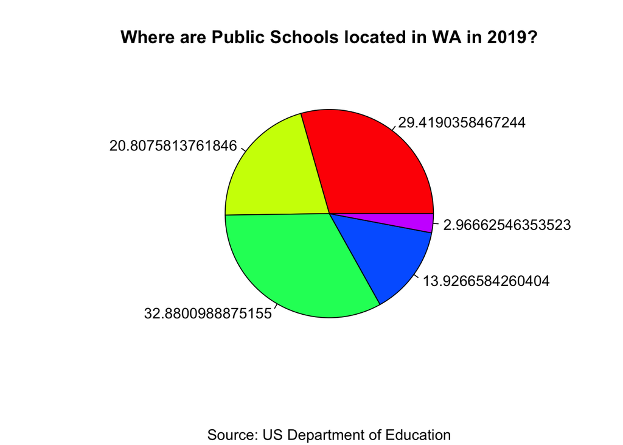

```r
# details:
ToPlot=ToPlot*100 # preparing labels
paletteHere=rainbow(length(ToPlot)) # customizing set of colors

# plotting
pie(x=ToPlot,#table
    col = paletteHere,
    labels = ToPlot,
    main=titleText,
    sub=sourceText)
```

The labels need better work:

```r
paste0(round(ToPlot,2),'%')
```

```
## [1] "29.42%" "20.81%" "32.88%" "13.93%" "2.97%"
```

Then,

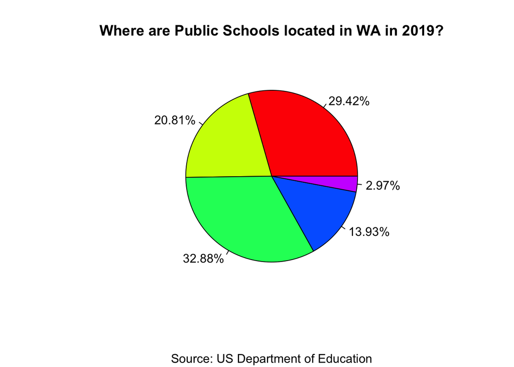

```r
plotLabels=paste0(round(ToPlot,2),'%') # labels for the slices
# plotting
pie(x=ToPlot,#table
    col = paletteHere,
    labels = plotLabels,
    main=titleText,
    sub=sourceText)
```

- You may need to use legends, but considering its cluttering effects:

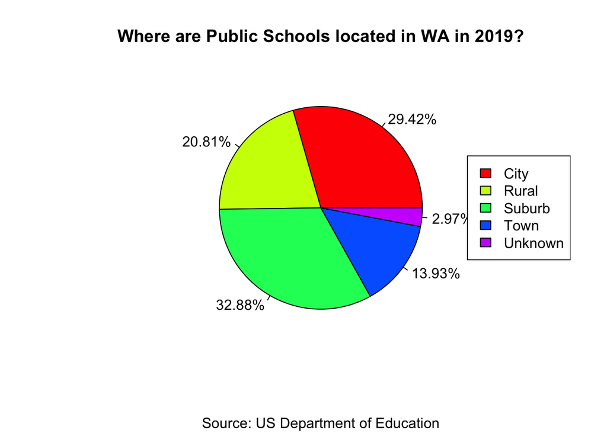

```r
# plotting
pie(x=ToPlot,#table
    col = paletteHere,
    labels = plotLabels,
    main=titleText,
    sub=sourceText)
#legend
legend(x="right", #where
       legend=names(ToPlot), #text
       fill = paletteHere) #symbols' colors
```

Most legends need customization:

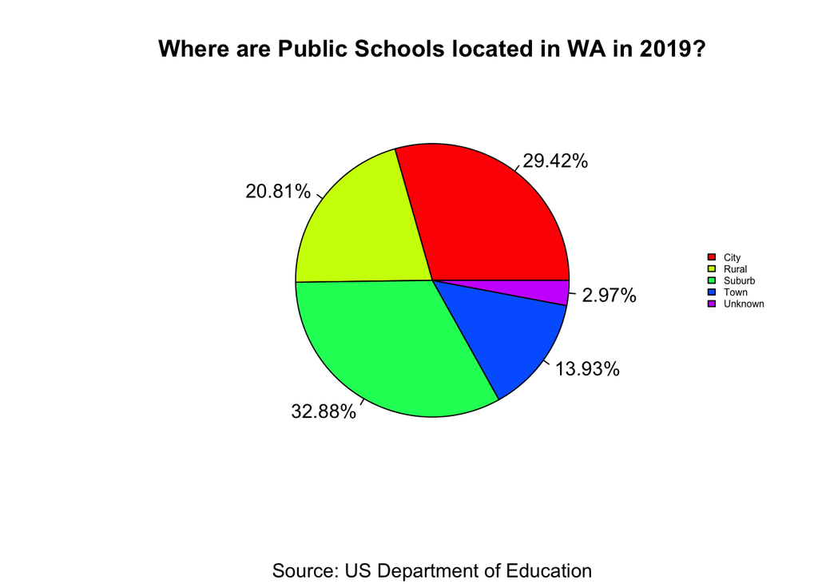

```r
# MANAGING THE LEGEND:

pie(x=ToPlot,#table
    col = paletteHere,
    labels = plotLabels,
    main=titleText,
    sub=sourceText)
#legend
legend(x="right", #where
       legend=names(ToPlot), #text
       fill = paletteHere,
       bty = 'n', # no box
       cex = 0.5  # shrink
       ) #symbols' colors
```

Most people tend to use pie charts with categorical data, but this **should not** be the default option to visualize classification (see this [discussion](https://medium.com/geckoboard-under-the-hood/think-before-you-pie-chart-and-more-effective-ways-to-visualize-your-data-862ea3456b26)). Following the advice from the [video](https://www.youtube.com/watch?v=axx_MYb8-SI) in that post, we should turn our pie into a **bar chart**. Let me do it with the same info I used to build the pie:

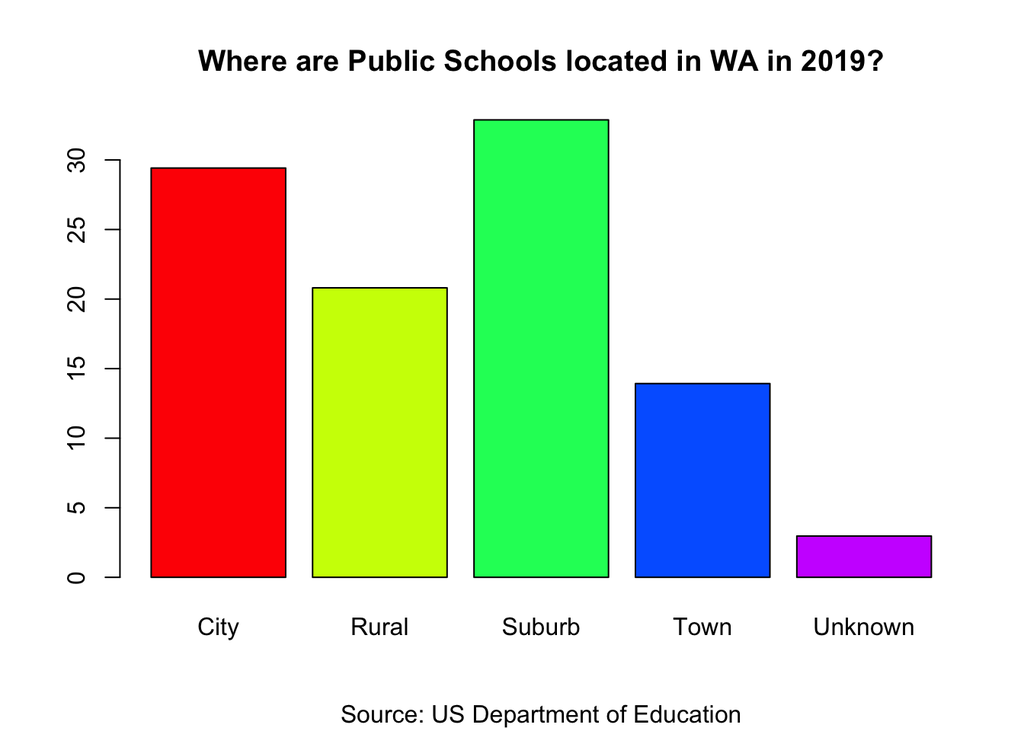

```r
# barplot plots the table too

barplot(ToPlot,
         col = paletteHere,
         main=titleText,
         sub=sourceText)
```

We saved some space as no legend was needed (the less **ink** the better visual). Speaking of saving, we can get rid of the colors (they were needed to differentiate the slices).

A very important thing to consider is that axes represent some unit of measurement, so make sure that unit is shown:

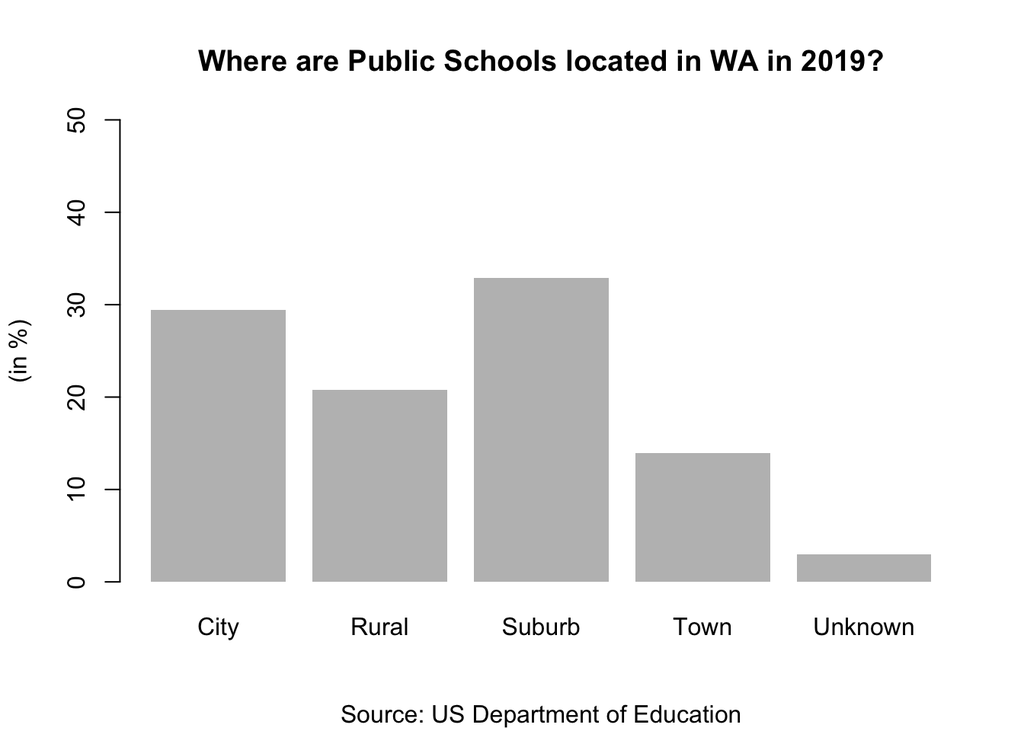

```r
paletteHereNew=c('gray') # just one color
# plotting
barplot(ToPlot,
     col = paletteHereNew,
     border=NA, #no border
     main=titleText,
     sub=sourceText,
     ylim=c(0,50),
     ylab = '(in %)' # show unit
     )
```

If you consider **annotating** the plot, you can use the labels we used before:

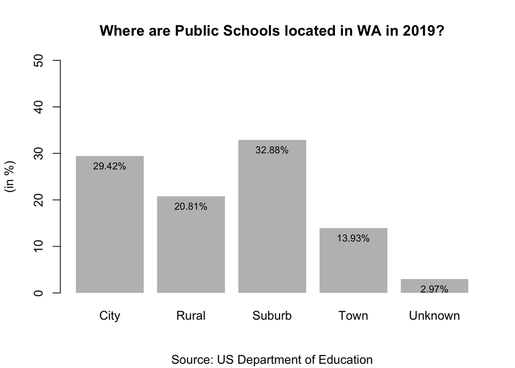

```r
# plotting
location=barplot(ToPlot,
     col = paletteHereNew,
     border=NA,
     main=titleText,
     sub=sourceText,
     ylim=c(0,50),
     ylab = '(in %)')

#annotating
text(x=location,y=ToPlot,labels=plotLabels,
     pos = 1,# if pos=3, text will be on top of bar
     cex = 0.8)
```

You may decide to change the **orientation** of the plot:

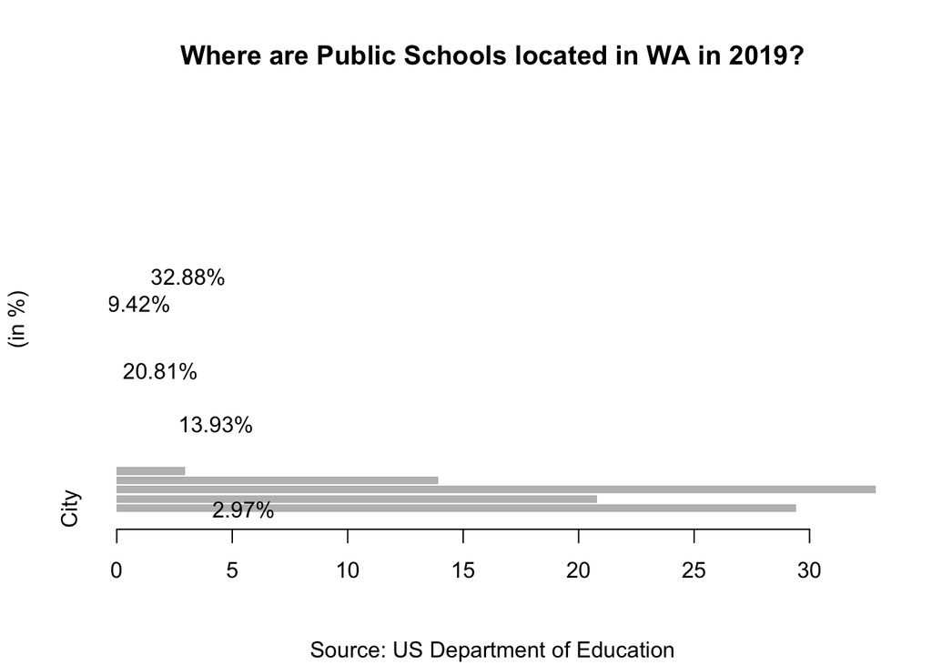

```r
# plotting
location=barplot(ToPlot,
     col = paletteHereNew,
     border=NA,
     main=titleText,
     sub=sourceText,
     ylim=c(0,50),
     ylab = '(in %)',
     horiz = T) # ORIENTATION

#annotating
text(x=location,y=ToPlot,labels=plotLabels,
     pos = 1) # this is the position of the label
```

The problem above is that changing the orientation, changes the axes. Then, we need to do more work:

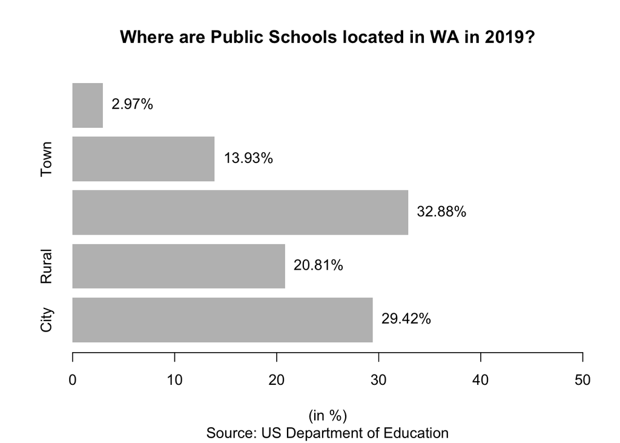

```r
location=barplot(ToPlot,
         col = paletteHereNew,
         border=NA,
         main=titleText,
         sub=sourceText,
         xlim=c(0,50), #change to xlim
         xlab = '(in %)', #change to xlab
         horiz = T)

#annotating
text(x=ToPlot,y=location, #change of x and y
     labels=plotLabels,
     pos = 4)  # change position of the label
```

A little more work on the categories names:

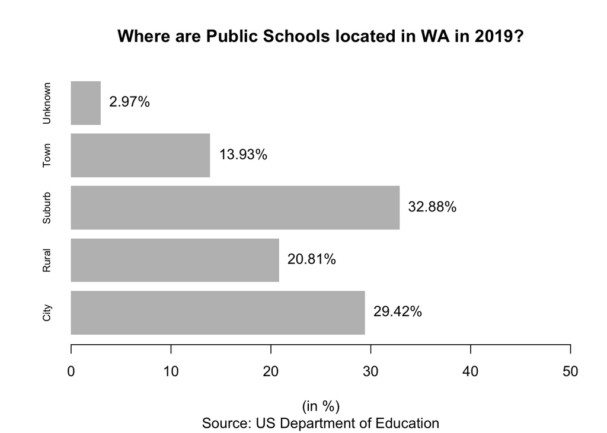

```r
location=barplot(ToPlot,
         col = paletteHereNew,
         border=NA,
         main=titleText,
         sub=sourceText,
         cex.names = 0.7, #shrink category names
         xlim=c(0,50),
         xlab = '(in %)',
         horiz = T)

#annotating
text(x=ToPlot,y=location,labels=plotLabels,pos = 4)
```

We made the right changes, but some things do not look well. It would be better if:

- The subtitle (*source*) and the label of the x-axis were not that close. A good step will be to have the subtitle as an element of its own, which allows, for instance, to decide its alignment and size:

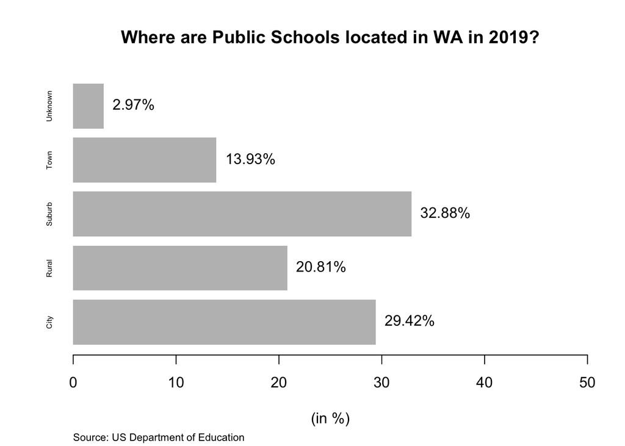

```r
location=barplot(ToPlot,
         col = paletteHereNew,
         border=NA,
         main=titleText, # no sub here!
         xlim=c(0,50),
         cex.names = 0.5,
         xlab = '(in %)',
         horiz = T)

# annotating
text(x=ToPlot,y=location,labels=plotLabels,pos = 4)

# subtitle
title(sub=sourceText,
      adj=0,#adj=1 aligns to rigth.
      cex.sub=0.7) #shrinking text
```

- To have the label of the x-axis closer to the axis itself, we need to alter the *graphical parameters*:

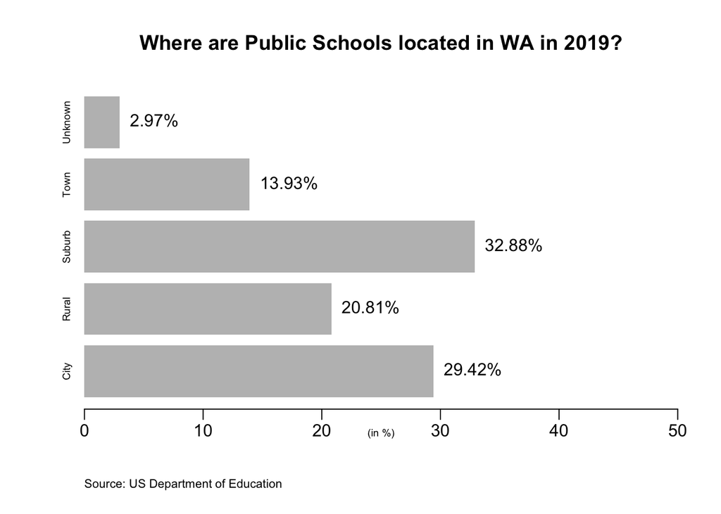

```r
# changing parameters
# (distanceOfUnit To plot,
# distanceOfAxislabels to plot,
# distance ofTicks to plot)
# default is: mgp=c(3, 1, 0)

par(mgp=c(0.5,0.5,0))
#####

location=barplot(ToPlot,
         col = paletteHereNew,
         border=NA,
         main=titleText,
         xlim=c(0,50),
         xlab = '(in %)',
         cex.names = 0.6,
         cex.lab=0.6, # shrinking label text
         horiz = T)

text(x=ToPlot,y=location,labels=plotLabels,pos = 4)

title(sub=sourceText, adj=0,cex.sub=0.7,
      line = 3) #push the text down
```

- It is generally a good idea to add a **reference line**, which can represent an expected value or another relevant value. Since I have four different locations (not considering the missing ones), let me put a line to signal the 25% (uniform share among four locations):

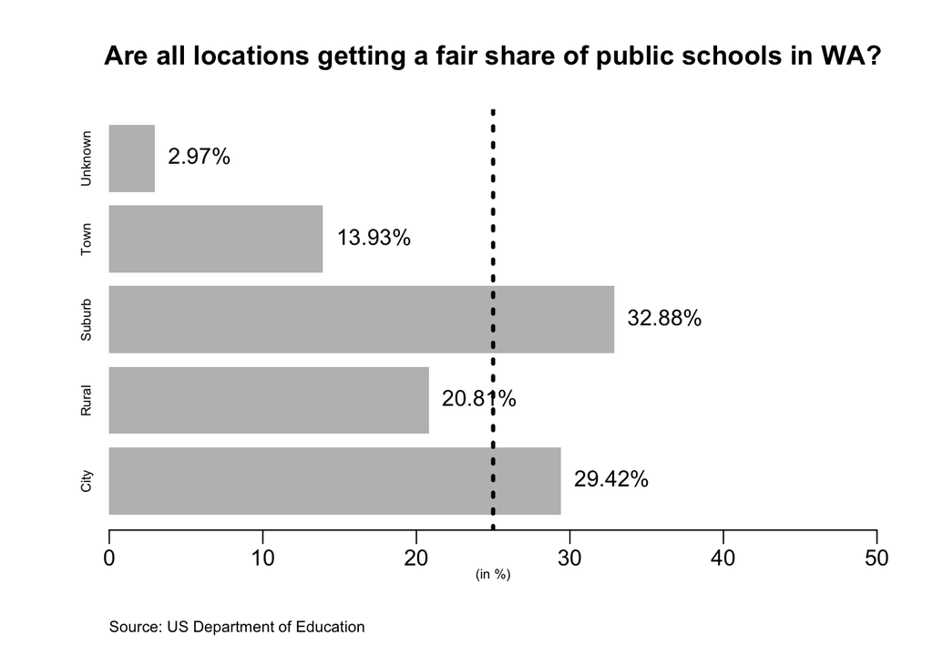

```r
titleText2='Are all locations getting a fair share of public schools in WA?'


par(mgp=c(1,0.5,0))
location=barplot(ToPlot,
         col = paletteHereNew,
         border=NA,
         main=titleText2,
         xlim=c(0,50),
         cex.names = 0.6,
         cex.lab=0.6,
         xlab = '(in %)',
         horiz = T
         )

text(x=ToPlot,y=location,labels=plotLabels,pos = 4)
title(sub=sourceText, adj=0,cex.sub=0.7,
      line = 3)

# reference line
abline(v=25,#position vertical
       lty=3,#type
       lwd=3)#width
```

Again, adding another element requires adjusting what we had. What about writing your own axis-values and reducing the bar annotations:

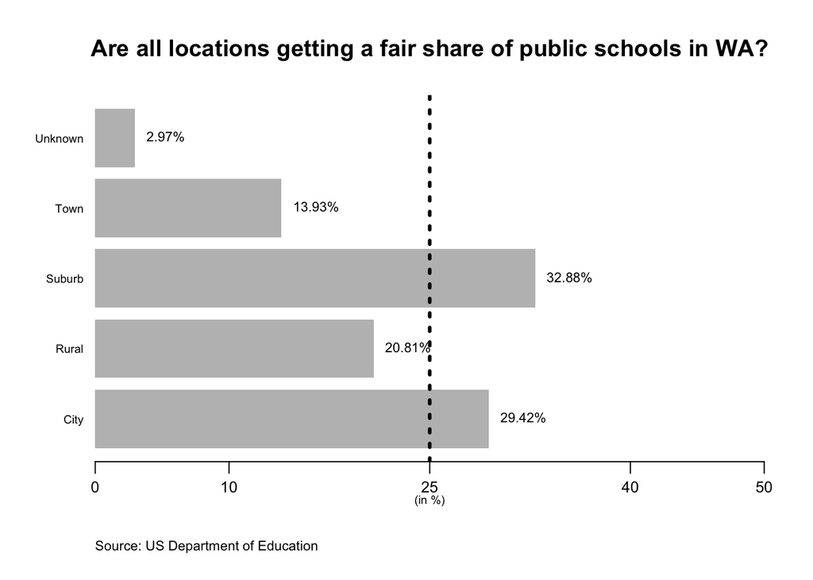

```r
par(mgp=c(1,0.5,0))
location=barplot(ToPlot,
         col = paletteHereNew,
         border=NA,
         main=titleText2,
         xlim=c(0,50),
         xlab = '(in %)',
         cex.names=0.6,
         cex.lab=0.6,
         las=2, #label names horizontal
         horiz = T,
         xaxt="n") # no x-axis, so I customize it below...

text(x=ToPlot,
     y=location,
     labels=plotLabels,
     pos = 4, #label position
     cex = 0.7) #label text size

title(sub=sourceText,
      adj=0, #position of subtitle (source)
      cex.sub=0.7, #size of text
      line = 3) #distance from base of plot

#reference line
abline(v=25,
       lty=3, #line type
       lwd=3) #line width


# customizing tick values
newXvalues<-c(0,10,25,40,50) # you just want to show this on the axis
axis(side=1,
     at=newXvalues,
     labels = newXvalues,
     cex.axis=0.8) #size of text on axis
```

So far, we have used the *basic* R capabilities for plotting.

There are alternative libraries, like **ggplot2**, that are also frequently used. However, it has a different approach, which allows to add layers that let you customize your plot. The classic approach for ggplot is:

- Avoid missing values and prepare frequency table. We replaced the missing values (now they are ‘Unknown’). Here, you need to transform the *table* into a **data frame**:

```r
tableFreq=as.data.frame(ToPlot)
names(tableFreq)=c("locale","pct")
#you have:
tableFreq
```

```
##    locale       pct
## 1    City 29.419036
## 2   Rural 20.807581
## 3  Suburb 32.880099
## 4    Town 13.926658
## 5 Unknown  2.966625
```

- Call the library:

```r
library(ggplot2)
```

- Create the base *object*, which is not a plot, just informing the main variables:

```r
#base GGPLOT2 starts with a "base", telling WHAT VARIABLES TO PLOT
tableFreq$locale <- factor(tableFreq$locale, levels = tableFreq$locale[order(-tableFreq$pct)])
base= ggplot(data = tableFreq,
             aes(x = locale,
                 y = pct))
```

- On top of the previous object, add the layer that produces the main plots (the next layers will add or customize elements in the plot):

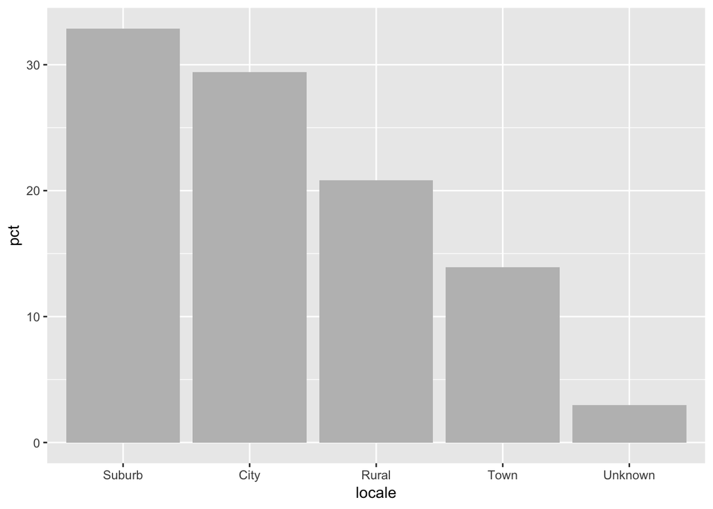

```r
plot1 = base + geom_bar(fill ="gray",
                        stat = "identity") # y is just what it is!
plot1
```

- We can now pay attention to the titles:

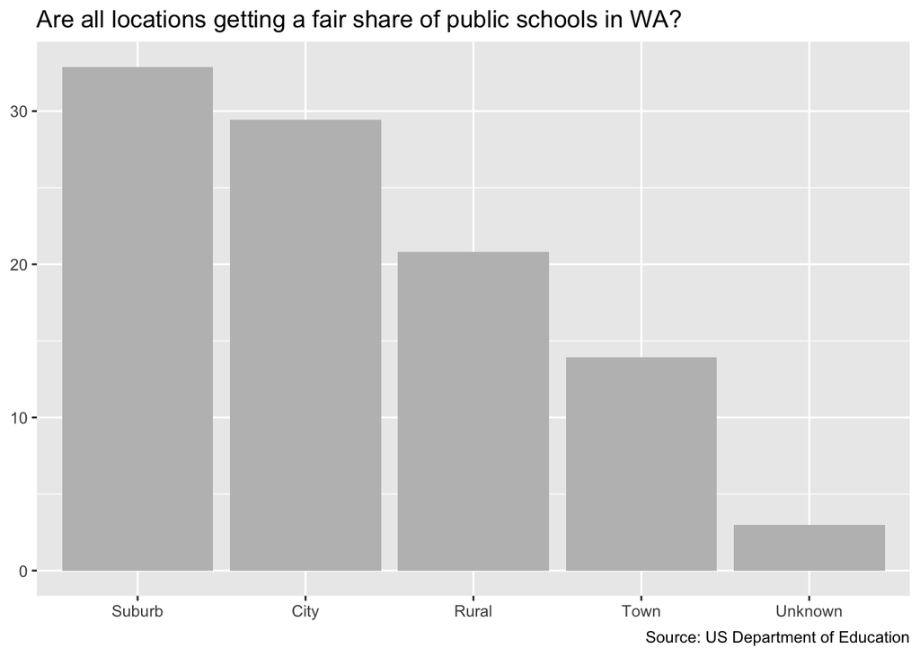

```r
plot2 = plot1 + labs(title=titleText2,
                     x =NULL,
                     y = NULL,
                     caption = sourceText)
plot2
```

- Add the reference lines:

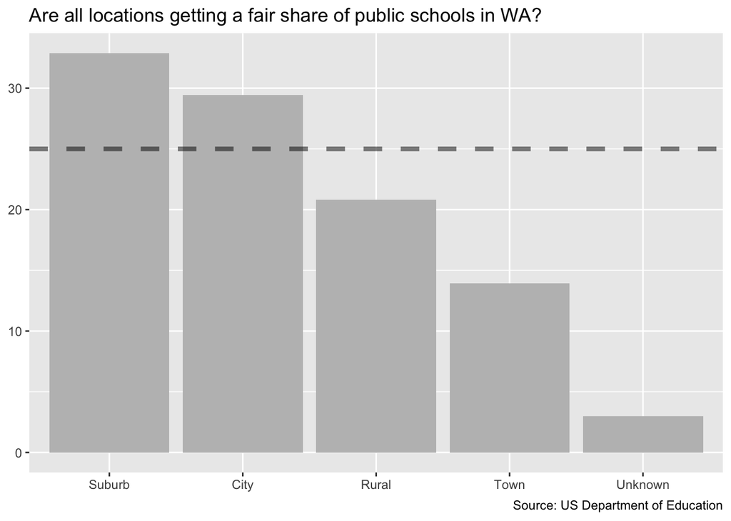

```r
plot3 = plot2 + geom_hline(yintercept = 25, #where
                           linetype="dashed",
                           size=1.5, #thickness
                           alpha=0.5) #transparency
plot3
```

- Customize the axes:

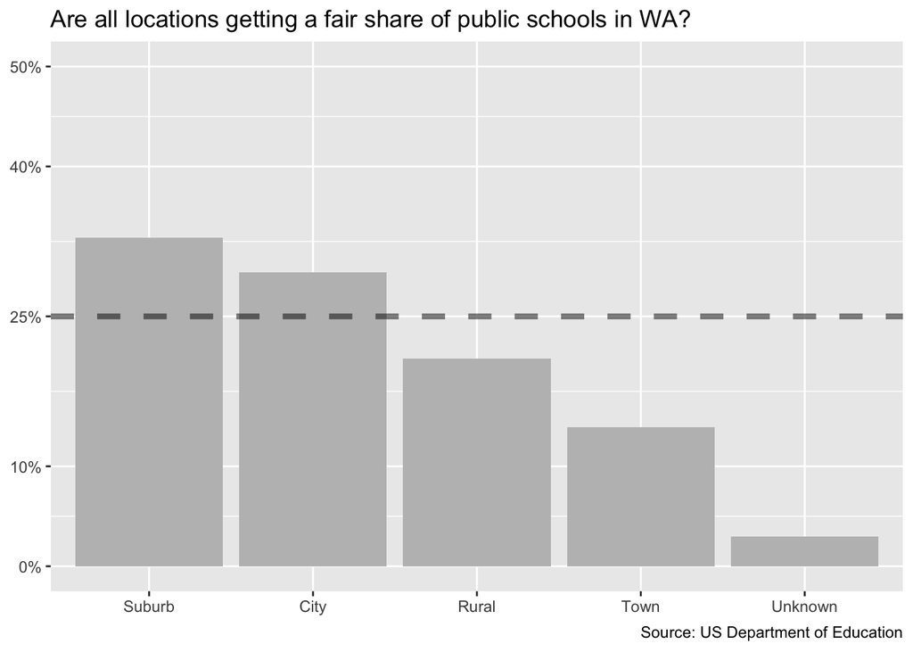

```r
library(scales)

# customize Y axis
plot4 = plot3 + scale_y_continuous(breaks=c(0,10, 25,40,50),
                                 limits = c(0, 50), # expand = c(0, 0),
                                 labels=scales::unit_format(suffix = '%'))
plot4
```

- Less ink and title/subtitle positions:

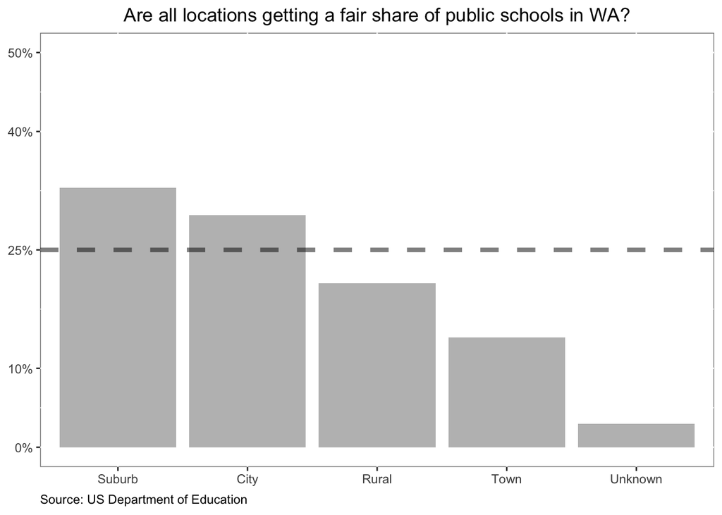

```r
plot5 = plot4 + theme(panel.background = element_rect(fill = "white",
                                                    colour = "grey50"),
                    plot.caption = element_text(hjust = 0), # default was 1
                    plot.title = element_text(hjust = 0.5))
plot5
```

- annotating the bars:

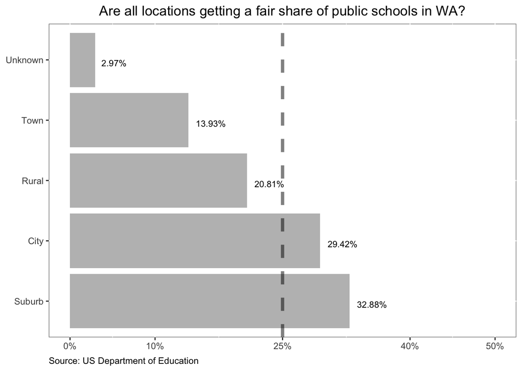

```r
plot6 = plot5 + geom_text(aes(y = pct ,
                            label = paste0(round(pct,2), '%')),
                        vjust=1, # if flipping 'hjust'
                        hjust=-0.25,
                        size = 3)
# wanna flip the plot?
plot6 + coord_flip()
```

Bar plots are the default option for categorical variables. In general, you see the distribution of the classification, which allows you to identify **concentration**. For that reason, ordering the bars by height can be helpful:

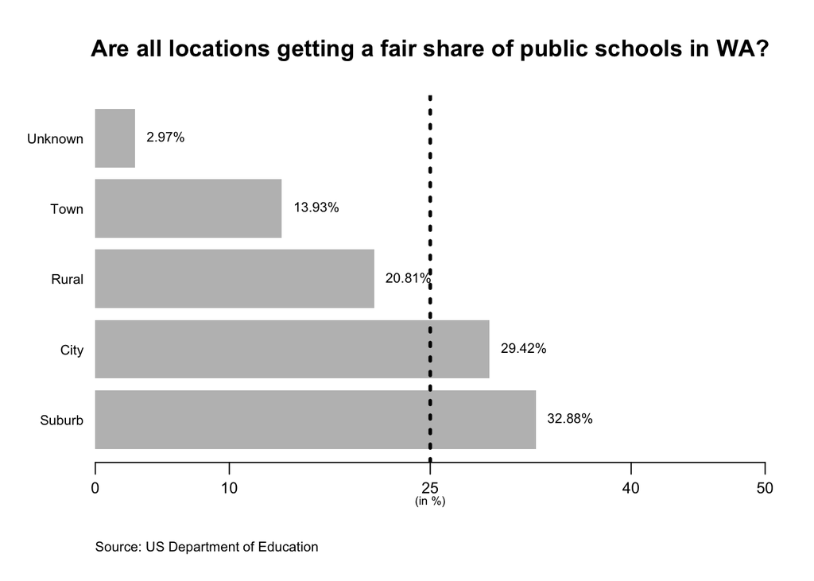

```r
###
ToPlotOrd=sort(ToPlot, decreasing = TRUE)
plotLabels=paste0(round(ToPlotOrd,2),'%') # labels for the slices
###

par(mgp=c(1,0.5,0)) # distance label, tickText,tick
location=barplot(ToPlotOrd,
         col = paletteHereNew,
         border=NA,
         main=titleText2,
         xlim=c(0,50),
         xlab = '(in %)',
         horiz = T,
         las = 2,
         cex.names = 0.7,
         cex.lab=0.6,
         xaxt="n") # no x-axis, so I customize it below...

text(x=ToPlotOrd,y=location,labels=plotLabels,pos = 4,cex = 0.7)
title(sub=sourceText, adj=0,cex.sub=0.7,line = 3)

# reference line
abline(v=25,lty=3,lwd=3)

# customizong tick values
xtick<-c(0,10,25,40,50)
axis(side=1, at=xtick, labels = xtick,cex.axis=0.8)
```

```r
tableFreq[order(-tableFreq$pct),]
```

```
##    locale       pct
## 3  Suburb 32.880099
## 1    City 29.419036
## 2   Rural 20.807581
## 4    Town 13.926658
## 5 Unknown  2.966625
```

Exercise:  
Use ggplot to show a bar plot ordered by share size.